# Analyse ouaouarons

# Ouaouaron

## Variable réponse (Présence ou absence du ouaouaron)

Les observations sont à 1 h en 2021 et 2022. Les visites à 15 h et 21 h n’ont pas été utilisé puisqu’il n’y avait qu’une à trois observations

Nombre d’observations 2021: 43

Nombre d’observations 2022: 32

Nombre de sites où l’espèce est observée 2021: 14

Nombre de sites où l’espèce est observée 2022: 15

Dates de visites (quand l’espèce est active) 2021: 27 mai au 7 juillet

Dates de visites (quand l’espèce est active) 2021: 25 mai au 20 juillet

```r
str(licat)
```

```
## 'data.frame':    52 obs. of  9 variables:
##  $ V1: int  0 0 0 0 0 0 NA 0 0 0 ...
##  $ V2: int  0 0 0 0 0 0 1 0 1 0 ...
##  $ V3: int  0 0 0 0 0 0 0 0 0 0 ...
##  $ V4: int  0 0 0 0 0 0 0 0 0 0 ...
##  $ V5: int  0 0 0 0 0 0 1 0 0 0 ...
##  $ V6: int  0 0 0 0 0 0 1 0 1 1 ...
##  $ V7: int  0 0 0 0 0 0 1 0 0 0 ...
##  $ V8: int  NA NA NA NA NA NA NA NA NA NA ...
##  $ V9: int  NA NA NA NA NA NA NA NA NA NA ...
```

## Variables de détection

- **Types de Perturbation** : Human, meteo ou none
- **Qualité de l’enregistrement** : Good, moderate ou bad
- **Date de l’enregistrement**: en jour julien
- **Année**: 2021 ou 2022

```r
str(jj_licat)
```

```
## 'data.frame':    52 obs. of  9 variables:
##  $ V1: int  145 145 145 145 145 145 NA 145 145 145 ...
##  $ V2: int  152 152 152 152 152 152 152 152 152 152 ...
##  $ V3: int  159 159 159 159 159 159 159 159 159 159 ...
##  $ V4: int  166 166 166 166 166 166 166 166 166 166 ...
##  $ V5: int  173 173 173 173 173 173 173 173 173 173 ...
##  $ V6: int  180 180 180 180 180 180 180 180 180 180 ...
##  $ V7: int  187 187 187 187 187 187 187 187 187 187 ...
##  $ V8: int  NA NA NA NA NA NA NA NA NA NA ...
##  $ V9: int  NA NA NA NA NA NA NA NA NA NA ...
```

```r
annee_licat$V1<-as.factor(annee_licat$V1)
annee_licat$V2<-as.factor(annee_licat$V2)
annee_licat$V3<-as.factor(annee_licat$V3)
annee_licat$V4<-as.factor(annee_licat$V4)
annee_licat$V5<-as.factor(annee_licat$V5)
annee_licat$V6<-as.factor(annee_licat$V6)
annee_licat$V7<-as.factor(annee_licat$V7)
annee_licat$V8<-factor(annee_licat$V8, levels = c("2021", "2022"))
annee_licat$V9<-factor(annee_licat$V9, levels = c("2021", "2022"))
str(annee_licat)
```

```
## 'data.frame':    52 obs. of  9 variables:
##  $ V1: Factor w/ 2 levels "2021","2022": 1 1 1 1 1 1 NA 1 1 1 ...
##  $ V2: Factor w/ 2 levels "2021","2022": 1 1 1 1 1 1 1 1 1 1 ...
##  $ V3: Factor w/ 2 levels "2021","2022": 1 1 1 1 1 1 1 1 1 1 ...
##  $ V4: Factor w/ 2 levels "2021","2022": 1 1 1 1 1 1 1 1 1 1 ...
##  $ V5: Factor w/ 2 levels "2021","2022": 1 1 1 1 1 1 1 1 1 1 ...
##  $ V6: Factor w/ 2 levels "2021","2022": 1 1 1 1 1 1 1 1 1 1 ...
##  $ V7: Factor w/ 2 levels "2021","2022": 1 1 1 1 1 1 1 1 1 1 ...
##  $ V8: Factor w/ 2 levels "2021","2022": NA NA NA NA NA NA NA NA NA NA ...
##  $ V9: Factor w/ 2 levels "2021","2022": NA NA NA NA NA NA NA NA NA NA ...
```

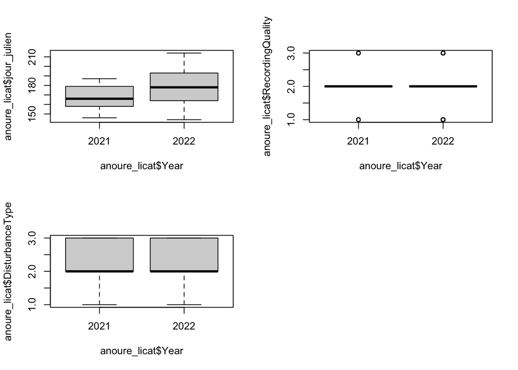

```r
par(mfrow=c(2,2))
boxplot(anoure_licat$jour_julien ~ anoure_licat$Year)
boxplot(anoure_licat$RecordingQuality ~ anoure_licat$Year)
boxplot(anoure_licat$DisturbanceType ~ anoure_licat$Year)
```

## Variables d’occupation

- **Milieux humide** : Regroupement de Milieu humide, Tourbières et Marécage (à partir de la couche de milieu humide)
- **Eau libre** : Regroupement de Marais, Lac, Eau peu profonde et Eau (à partir de la couche de milieu humide et la couche d’utilisation du territoire)
- **Route** : Nombre de km de route total
- **Agriculture** : Regroupement de tous les types d’agriculture
- **Site** : Si le site est en lisière ou en forêt (donnée prise lors de la pause des enregistreurs)

```r
str(occupation)
```

```
## 'data.frame':    52 obs. of  7 variables:
##  $ Enregistre : chr  "C-foret" "C-lisiere" "E-foret" "E-lisiere" ...
##  $ Route      : num  0 0.00192 0 0.00185 0 ...
##  $ Agriculture: num  5.69e-02 2.23e-01 2.93e-03 1.87e-02 1.82e-05 ...
##  $ Eau        : num  0 0 0 0 0.211 ...
##  $ Humide     : num  0.927 0.782 0.999 0.89 0.875 ...
##  $ Site       : chr  "foret" "lisiere" "foret" "lisiere" ...
##  $ annee      : int  2021 2021 2021 2021 2021 2021 2021 2021 2021 2021 ...
```

Standardiser occupation

```r
occupation$Route <- scale(occupation$Route)
occupation$Agriculture <- scale(occupation$Agriculture)
occupation$Eau <- scale(occupation$Eau)
occupation$Humide <- scale(occupation$Humide)
occupation$Site <- as.factor(occupation$Site)
occupation$annee <- as.factor(occupation$annee)
str(occupation)
```

```
## 'data.frame':    52 obs. of  7 variables:
##  $ Enregistre : chr  "C-foret" "C-lisiere" "E-foret" "E-lisiere" ...
##  $ Route      : num [1:52, 1] -0.534 1.266 -0.534 1.204 -0.534 ...
##   ..- attr(*, "scaled:center")= num 0.00057
##   ..- attr(*, "scaled:scale")= num 0.00107
##  $ Agriculture: num [1:52, 1] -0.904 0.488 -1.358 -1.225 -1.382 ...
##   ..- attr(*, "scaled:center")= num 0.164
##   ..- attr(*, "scaled:scale")= num 0.119
##  $ Eau        : num [1:52, 1] -0.507 -0.507 -0.507 -0.507 1.477 ...
##   ..- attr(*, "scaled:center")= num 0.0539
##   ..- attr(*, "scaled:scale")= num 0.106
##  $ Humide     : num [1:52, 1] 0.806 0.324 1.044 0.682 0.631 ...
##   ..- attr(*, "scaled:center")= num 0.685
##   ..- attr(*, "scaled:scale")= num 0.301
##  $ Site       : Factor w/ 2 levels "foret","lisiere": 1 2 1 2 1 2 2 1 2 2 ...
##  $ annee      : Factor w/ 2 levels "2021","2022": 1 1 1 1 1 1 1 1 1 1 ...
```

## Création des modèles

Création du tableau de données pour le package unmarked

```r
licat.data <- unmarkedFrameOccu(y = licat, siteCovs = occupation, obsCovs = list(disturbance = perturb_licat, qualite = qualite_licat, annee = annee_licat, date = jj_licat))
summary(licat.data)
```

```
## unmarkedFrame Object
##
## 52 sites
## Maximum number of observations per site: 9
## Mean number of observations per site: 7.87
## Sites with at least one detection: 29
##
## Tabulation of y observations:
##    0    1 <NA>
##  334   75   59
##
## Site-level covariates:
##      Enregistre      Route.V1          Agriculture.V1          Eau.V1
##  C-foret  : 2   Min.   :-0.533749   Min.   :-1.3822187   Min.   :-0.506607
##  C-lisiere: 2   1st Qu.:-0.533749   1st Qu.:-0.8280295   1st Qu.:-0.506607
##  E-foret  : 2   Median :-0.533749   Median :-0.0956250   Median :-0.506607
##  E-lisiere: 2   Mean   : 0.000000   Mean   : 0.0000000   Mean   : 0.000000
##  F-foret  : 2   3rd Qu.: 0.242135   3rd Qu.: 0.9551753   3rd Qu.:-0.092254
##  F-lisiere: 2   Max.   : 3.400776   Max.   : 1.6454316   Max.   : 3.259940
##  (Other)  :40
##       Humide.V1            Site     annee
##  Min.   :-2.2743320   foret  :18   2021:26
##  1st Qu.:-0.0631602   lisiere:34   2022:26
##  Median : 0.3195280
##  Mean   : 0.0000000
##  3rd Qu.: 0.6310244
##  Max.   : 1.0480255
##
##
## Observation-level covariates:
##  disturbance     qualite     annee          date
##  human: 78   bad     : 60   2021:176   Min.   :144.0
##  meteo:224   good    :148   2022:233   1st Qu.:158.0
##  none :107   moderate:201   NA's: 59   Median :172.0
##  NA's : 59   NA's    : 59              Mean   :169.7
##                                        3rd Qu.:184.5
##                                        Max.   :200.0
##                                        NA's   :58
```

Modèles

```r
#Détectabilité et occupation constante
m0 <- occu(~ annee ~ annee, data = licat.data)

##Détectabilité varie selon la qualité de l'enregistrement et l'occupation varie selon...
mQH <- occu(~ qualite + annee ~ Humide + annee, data = licat.data)
mQE <- occu(~ qualite + annee ~ Eau + annee, data = licat.data)
mQR <- occu(~ qualite + annee ~ Route + annee, data = licat.data)
mQA <- occu(~ qualite + annee ~ Agriculture + annee, data = licat.data)
mQS <- occu(~ qualite + annee ~ Site + annee, data = licat.data)

##Détectabilité varie selon le type de perturbation et occupation varie selon ...
mPH <- occu(~ disturbance + annee ~ Humide + annee, data = licat.data)
mPE <- occu(~ disturbance + annee ~ Eau + annee, data = licat.data)
mPR <- occu(~ disturbance + annee ~ Route + annee, data = licat.data)
mPA <- occu(~ disturbance + annee ~ Agriculture + annee, data = licat.data)
mPS <- occu(~ disturbance + annee ~ Site + annee, data = licat.data)

##Détectabilité varie selon l'année et occupation varie selon ...
mAH <- occu(~ annee ~ Humide + annee, data = licat.data)
mAE <- occu(~ annee ~ Eau + annee, data = licat.data)
mAR <- occu(~ annee ~ Route + annee, data = licat.data)
mAA <- occu(~ annee ~ Agriculture + annee, data = licat.data)
mAS <- occu(~ annee ~ Site + annee, data = licat.data)

##Détectabilité varie selon les jours juliens et occupation varie selon ...
mDH <- occu(~ date ~ Humide + annee, data = licat.data)
mDE <- occu(~ date ~ Eau + annee, data = licat.data)
mDR <- occu(~ date ~ Route + annee, data = licat.data)
mDA <- occu(~ date ~ Agriculture + annee, data = licat.data)
mDS <- occu(~ date ~ Site + annee, data = licat.data)
```

Tableau de tous les modèles avec le poid AIC

```r
Cands <- list(m0, mQH, mQE, mQR, mQA, mQS, mPH, mPE, mPR, mPA, mPS, mAH, mAE, mAR, mAA, mAS, mDH, mDE, mDR, mDA, mDS)

##Donner les noms significaifs aux modèles
Model.names <- c("nul","psi(Milieux humides)p(Qualité)", "psi(Eau libre)p(Qualité)", "psi(Route)p(Qualité)", "psi(Agriculture)p(Qualité)", "psi(Site)p(Qualité)", "psi(Milieux humides)p(Perturb)", "psi(Eau libre)p(Perturb)", "psi(Route)p(Perturb)", "psi(Agriculture)p(Perturb)", "psi(Site)p(Perturb)", "psi(Milieux humides)p(Année)", "psi(Eau libre)p(Année)", "psi(Route)p(Année)", "psi(Agriculture)p(Année)", "psi(Site)p(Année)", "psi(Milieux humides)p(Date)", "psi(Eau libre)p(Date)", "psi(Route)p(Date)", "psi(Agriculture)p(Date)", "psi(Site)p(Date)")

##do model selection based on AICc
aictab(cand.set = Cands,  modnames = Model.names)
```

```
##
## Model selection based on AICc:
##
##                                K   AICc Delta_AICc AICcWt Cum.Wt      LL
## psi(Agriculture)p(Qualité)     7 315.35       0.00   0.62   0.62 -149.40
## psi(Milieux humides)p(Qualité) 7 316.85       1.50   0.29   0.91 -150.15
## psi(Site)p(Qualité)            7 321.06       5.71   0.04   0.94 -152.26
## psi(Route)p(Qualité)           7 321.15       5.80   0.03   0.98 -152.30
## psi(Eau libre)p(Qualité)       7 321.80       6.45   0.02   1.00 -152.63
## psi(Agriculture)p(Perturb)     7 340.61      25.26   0.00   1.00 -162.03
## psi(Milieux humides)p(Perturb) 7 341.82      26.47   0.00   1.00 -162.64
## psi(Agriculture)p(Année)       5 346.28      30.93   0.00   1.00 -167.49
## psi(Route)p(Perturb)           7 346.43      31.08   0.00   1.00 -164.94
## psi(Site)p(Perturb)            7 346.60      31.24   0.00   1.00 -165.03
## psi(Milieux humides)p(Année)   5 346.66      31.31   0.00   1.00 -167.68
## psi(Eau libre)p(Perturb)       7 346.93      31.58   0.00   1.00 -165.19
## nul                            4 351.47      36.11   0.00   1.00 -171.31
## psi(Route)p(Année)             5 352.06      36.71   0.00   1.00 -170.38
## psi(Site)p(Année)              5 352.25      36.89   0.00   1.00 -170.47
## psi(Eau libre)p(Année)         5 352.56      37.21   0.00   1.00 -170.63
## psi(Milieux humides)p(Date)    5 358.54      43.19   0.00   1.00 -173.62
## psi(Agriculture)p(Date)        5 359.92      44.57   0.00   1.00 -174.31
## psi(Route)p(Date)              5 364.02      48.67   0.00   1.00 -176.36
## psi(Site)p(Date)               5 364.35      49.00   0.00   1.00 -176.52
## psi(Eau libre)p(Date)          5 364.50      49.15   0.00   1.00 -176.60
```

### Vérification ajustement du modèle

```r
mQE
```

```
##
## Call:
## occu(formula = ~qualite + annee ~ Eau + annee, data = licat.data)
##
## Occupancy:
##             Estimate    SE      z P(>|z|)
## (Intercept)    0.191 0.407  0.469   0.639
## Eau           -0.306 0.321 -0.955   0.340
## annee2022      0.496 0.677  0.732   0.464
##
## Detection:
##                 Estimate     SE      z P(>|z|)
## (Intercept)       -10.62 51.019 -0.208 0.83513
## qualitegood        11.26 51.019  0.221 0.82535
## qualitemoderate    10.21 51.019  0.200 0.84143
## annee2022          -1.26  0.357 -3.521 0.00043
##
## AIC: 319.2586
```

```r
mQR
```

```
##
## Call:
## occu(formula = ~qualite + annee ~ Route + annee, data = licat.data)
##
## Occupancy:
##             Estimate    SE      z P(>|z|)
## (Intercept)    0.189 0.410  0.461   0.645
## Route         -0.415 0.337 -1.232   0.218
## annee2022      0.521 0.689  0.755   0.450
##
## Detection:
##                 Estimate      SE      z  P(>|z|)
## (Intercept)       -12.27 116.307 -0.105 0.916006
## qualitegood        12.91 116.307  0.111 0.911630
## qualitemoderate    11.85 116.307  0.102 0.918819
## annee2022          -1.26   0.356 -3.539 0.000402
##
## AIC: 318.6092
```

Code ajustement du modèle

```r
ajust <- mb.gof.test(mQH, nsim = 5000, plot.hist=T)
save(ajust, file = "licat_ajust_gof.Rdata")
```

```r
load("licat_ajust_gof.Rdata")
ajust
```

```
##
## MacKenzie and Bailey goodness-of-fit for single-season occupancy model
##
## Pearson chi-square table:
##
##           Cohort Observed Expected Chi-square
## 000000000      0       10    10.82       0.06
## 000001000      0        1     0.33       1.40
## 000001011      0        2     0.14      25.10
## 000101000      0        1     0.25       2.21
## 010000000      0        3     0.24      32.27
## 100000000      0        1     0.31       1.53
## 100001000      0        2     0.23      13.65
## 100101000      0        1     0.18       3.65
## 110000000      0        1     0.17       3.99
## 110100000      0        2     0.14      25.06
## 110101000      0        1     0.10       7.70
## 0000000.0      1        1     0.33       1.32
## 0000000..      2       12     9.18       0.87
## 0000010..      2        2     0.58       3.53
## 0000110..      2        1     0.37       1.06
## 0100010..      2        1     0.31       1.50
## 0100111..      2        1     0.10       8.42
## 0101110..      2        1     0.03      26.82
## 1010011..      2        1     0.04      22.00
## 1110111..      2        1     0.01      70.55
## 010.011..      3        1     0.01      94.37
## .000110..      4        1     0.13       5.74
## .100110..      4        1     0.06      15.08
## .100111..      4        2     0.03     121.71
## .110100..      4        1     0.03      29.27
##
## Chi-square statistic = 546.7197
## Number of bootstrap samples = 5000
## P-value = 0.8142
##
## Quantiles of bootstrapped statistics:
##    0%   25%   50%   75%  100%
##   182   592   753   985 11245
##
## Estimate of c-hat = 0.63
```

Pas besoin de réajuster le modèle puisque le c-hat (0.63) est < à 1

### Inférence multimodèles

Est-ce que j’ignore les warnings?

#### Inférence avec shrinkage

```r
modavgShrink(cand.set = Cands, modnames = Model.names, parm = "Eau", parm.type = "psi")
```

```
## Warning in modavgShrink.AICunmarkedFitOccu(cand.set = Cands, modnames = Model.names, :
## Variables do not appear with same frequency across models, proceed with caution
```

```
##
## Multimodel inference on "psi(Eau)" based on AICc
##
## AICc table used to obtain model-averaged estimate with shrinkage:
##
##                                K   AICc Delta_AICc AICcWt Estimate   SE
## nul                            4 351.47      36.11   0.00     0.00 0.00
## psi(Milieux humides)p(Qualité) 7 316.85       1.50   0.29     0.00 0.00
## psi(Eau libre)p(Qualité)       7 321.80       6.45   0.02    -0.31 0.32
## psi(Route)p(Qualité)           7 321.15       5.80   0.03     0.00 0.00
## psi(Agriculture)p(Qualité)     7 315.35       0.00   0.62     0.00 0.00
## psi(Site)p(Qualité)            7 321.06       5.71   0.04     0.00 0.00
## psi(Milieux humides)p(Perturb) 7 341.82      26.47   0.00     0.00 0.00
## psi(Eau libre)p(Perturb)       7 346.93      31.58   0.00    -0.34 0.31
## psi(Route)p(Perturb)           7 346.43      31.08   0.00     0.00 0.00
## psi(Agriculture)p(Perturb)     7 340.61      25.26   0.00     0.00 0.00
## psi(Site)p(Perturb)            7 346.60      31.24   0.00     0.00 0.00
## psi(Milieux humides)p(Année)   5 346.66      31.31   0.00     0.00 0.00
## psi(Eau libre)p(Année)         5 352.56      37.21   0.00    -0.36 0.32
## psi(Route)p(Année)             5 352.06      36.71   0.00     0.00 0.00
## psi(Agriculture)p(Année)       5 346.28      30.93   0.00     0.00 0.00
## psi(Site)p(Année)              5 352.25      36.89   0.00     0.00 0.00
## psi(Milieux humides)p(Date)    5 358.54      43.19   0.00     0.00 0.00
## psi(Eau libre)p(Date)          5 364.50      49.15   0.00    -0.33 0.31
## psi(Route)p(Date)              5 364.02      48.67   0.00     0.00 0.00
## psi(Agriculture)p(Date)        5 359.92      44.57   0.00     0.00 0.00
## psi(Site)p(Date)               5 364.35      49.00   0.00     0.00 0.00
##
## Model-averaged estimate with shrinkage: -0.01
## Unconditional SE: 0.07
## 95% Unconditional confidence interval: -0.14, 0.13
```

```r
modavgShrink(cand.set = Cands, modnames = Model.names, parm = "Route", parm.type = "psi")
```

```
##
## Multimodel inference on "psi(Route)" based on AICc
##
## AICc table used to obtain model-averaged estimate with shrinkage:
##
##                                K   AICc Delta_AICc AICcWt Estimate   SE
## nul                            4 351.47      36.11   0.00     0.00 0.00
## psi(Milieux humides)p(Qualité) 7 316.85       1.50   0.29     0.00 0.00
## psi(Eau libre)p(Qualité)       7 321.80       6.45   0.02     0.00 0.00
## psi(Route)p(Qualité)           7 321.15       5.80   0.03    -0.41 0.34
## psi(Agriculture)p(Qualité)     7 315.35       0.00   0.62     0.00 0.00
## psi(Site)p(Qualité)            7 321.06       5.71   0.04     0.00 0.00
## psi(Milieux humides)p(Perturb) 7 341.82      26.47   0.00     0.00 0.00
## psi(Eau libre)p(Perturb)       7 346.93      31.58   0.00     0.00 0.00
## psi(Route)p(Perturb)           7 346.43      31.08   0.00    -0.42 0.33
## psi(Agriculture)p(Perturb)     7 340.61      25.26   0.00     0.00 0.00
## psi(Site)p(Perturb)            7 346.60      31.24   0.00     0.00 0.00
## psi(Milieux humides)p(Année)   5 346.66      31.31   0.00     0.00 0.00
## psi(Eau libre)p(Année)         5 352.56      37.21   0.00     0.00 0.00
## psi(Route)p(Année)             5 352.06      36.71   0.00    -0.44 0.33
## psi(Agriculture)p(Année)       5 346.28      30.93   0.00     0.00 0.00
## psi(Site)p(Année)              5 352.25      36.89   0.00     0.00 0.00
## psi(Milieux humides)p(Date)    5 358.54      43.19   0.00     0.00 0.00
## psi(Eau libre)p(Date)          5 364.50      49.15   0.00     0.00 0.00
## psi(Route)p(Date)              5 364.02      48.67   0.00    -0.40 0.31
## psi(Agriculture)p(Date)        5 359.92      44.57   0.00     0.00 0.00
## psi(Site)p(Date)               5 364.35      49.00   0.00     0.00 0.00
##
## Model-averaged estimate with shrinkage: -0.01
## Unconditional SE: 0.1
## 95% Unconditional confidence interval: -0.2, 0.18
```

```r
modavgShrink(cand.set = Cands, modnames = Model.names, parm = "qualitegood", parm.type = "detect")
```

```
##
## Multimodel inference on "p(qualitegood)" based on AICc
##
## AICc table used to obtain model-averaged estimate with shrinkage:
##
##                                K   AICc Delta_AICc AICcWt Estimate     SE
## nul                            4 351.47      36.11   0.00     0.00   0.00
## psi(Milieux humides)p(Qualité) 7 316.85       1.50   0.29    11.45  56.73
## psi(Eau libre)p(Qualité)       7 321.80       6.45   0.02    11.26  51.02
## psi(Route)p(Qualité)           7 321.15       5.80   0.03    12.91 116.31
## psi(Agriculture)p(Qualité)     7 315.35       0.00   0.62     9.73  23.99
## psi(Site)p(Qualité)            7 321.06       5.71   0.04    11.14  47.72
## psi(Milieux humides)p(Perturb) 7 341.82      26.47   0.00     0.00   0.00
## psi(Eau libre)p(Perturb)       7 346.93      31.58   0.00     0.00   0.00
## psi(Route)p(Perturb)           7 346.43      31.08   0.00     0.00   0.00
## psi(Agriculture)p(Perturb)     7 340.61      25.26   0.00     0.00   0.00
## psi(Site)p(Perturb)            7 346.60      31.24   0.00     0.00   0.00
## psi(Milieux humides)p(Année)   5 346.66      31.31   0.00     0.00   0.00
## psi(Eau libre)p(Année)         5 352.56      37.21   0.00     0.00   0.00
## psi(Route)p(Année)             5 352.06      36.71   0.00     0.00   0.00
## psi(Agriculture)p(Année)       5 346.28      30.93   0.00     0.00   0.00
## psi(Site)p(Année)              5 352.25      36.89   0.00     0.00   0.00
## psi(Milieux humides)p(Date)    5 358.54      43.19   0.00     0.00   0.00
## psi(Eau libre)p(Date)          5 364.50      49.15   0.00     0.00   0.00
## psi(Route)p(Date)              5 364.02      48.67   0.00     0.00   0.00
## psi(Agriculture)p(Date)        5 359.92      44.57   0.00     0.00   0.00
## psi(Site)p(Date)               5 364.35      49.00   0.00     0.00   0.00
##
## Model-averaged estimate with shrinkage: 10.43
## Unconditional SE: 43.52
## 95% Unconditional confidence interval: -74.87, 95.72
```

```r
##data frame to make predictions
##all variables are held constant, except Shade
extractX(cand.set = Cands, modnames = Model.names, parm.type = "psi")
```

```
##
## Predictors appearing in candidate models:
## annee    Humide    Eau    Route    Agriculture    Site
##
## Structure of predictors in obsCovs:
##  $ annee: Factor w/ 2 levels "2021","2022": 1 1 1 1 1 1 1 NA NA 1 ...
##
## Structure of predictors in siteCovs:
##  $ annee      : Factor w/ 2 levels "2021","2022": 1 1 1 1 1 1 1 1 1 1 ...
##  $ Humide     : num [1:52, 1] 0.806 0.324 1.044 0.682 0.631 ...
##   ..- attr(*, "scaled:center")= num 0.685
##   ..- attr(*, "scaled:scale")= num 0.301
##  $ Eau        : num [1:52, 1] -0.507 -0.507 -0.507 -0.507 1.477 ...
##   ..- attr(*, "scaled:center")= num 0.0539
##   ..- attr(*, "scaled:scale")= num 0.106
##  $ Route      : num [1:52, 1] -0.534 1.266 -0.534 1.204 -0.534 ...
##   ..- attr(*, "scaled:center")= num 0.00057
##   ..- attr(*, "scaled:scale")= num 0.00107
##  $ Agriculture: num [1:52, 1] -0.904 0.488 -1.358 -1.225 -1.382 ...
##   ..- attr(*, "scaled:center")= num 0.164
##   ..- attr(*, "scaled:scale")= num 0.119
##  $ Site       : Factor w/ 2 levels "foret","lisiere": 1 2 1 2 1 2 2 1 2 2 ...
```

```r
predData <- data.frame(annee = factor("2021",
                                      levels = levels(occupation$annee)),
Eau = seq(-0.5, 3.25, length.out = 40),
Humide = c(0, 0),
Route = c(0, 0),
Agriculture = c(0, 0),
Site = factor("lisiere",
              levels = levels(occupation$Site))
)

##predictions from global model
predict(mQE, newdata = predData, se.fit = TRUE, type = "state")
```

```
##    Predicted        SE      lower     upper
## 1  0.5851152 0.1057448 0.37520352 0.7680927
## 2  0.5779519 0.1037957 0.37293549 0.7592161
## 3  0.5707556 0.1022816 0.36974185 0.7508581
## 4  0.5635294 0.1012400 0.36557842 0.7431164
## 5  0.5562760 0.1007014 0.36041760 0.7360767
## 6  0.5489986 0.1006870 0.35425211 0.7298085
## 7  0.5417001 0.1012076 0.34709762 0.7243613
## 8  0.5343838 0.1022627 0.33899368 0.7197631
## 9  0.5270525 0.1038410 0.33000272 0.7160201
## 10 0.5197097 0.1059211 0.32020738 0.7131184
## 11 0.5123582 0.1084734 0.30970639 0.7110273
## 12 0.5050015 0.1114620 0.29860973 0.7097026
## 13 0.4976425 0.1148471 0.28703364 0.7090913
## 14 0.4902846 0.1185866 0.27509596 0.7091350
```

[output cut: 26 more lines]

```r
modavgPred(cand.set = Cands, modnames = Model.names, newdata = predData, parm.type = "psi", type = "response")
```

```
##
## Model-averaged predictions on the response scale
## based on entire model set and 95% confidence interval:
##
##    mod.avg.pred uncond.se lower.CL upper.CL
## 1         0.561     0.115    0.339    0.762
## 2         0.561     0.115    0.338    0.762
## 3         0.561     0.115    0.338    0.761
## 4         0.561     0.115    0.338    0.761
## 5         0.560     0.115    0.338    0.761
## 6         0.560     0.115    0.338    0.761
## 7         0.560     0.115    0.338    0.761
## 8         0.560     0.115    0.338    0.761
## 9         0.560     0.115    0.337    0.761
## 10        0.560     0.115    0.337    0.761
```

[output cut: 30 more lines]